# Анализ популярности запросов с помощью Google Trends

Морозова Ю.А.

31 августа 2017 г

## Введение

Сервис [Google Trends](http://www.google.com/trends) позволяет легко отслеживать и сравнивать изменения популярности различных поисковых запросов. Это дает возможность измерить динамику таких трудноизмеряемых показателей, как уровень интереса пользователей Интернет к той или иной теме, популярность брендов и др. Например, можно отобразить на графике динамику популярности запросов “data scientist”, “data science” и “R programming”:

https://trends.google.com/trends/explore?date=all&q=data%20scientist,data%20science,R%20programming

[figure not shown]

Сервис *Google Trends* также позволяет выгружать данные с сайта в формате csv для дальнейшего анализа. Однако в R есть возможность выгрузки данных с сайта google непосредственно в R. Для этого удобно воспользоваться пакетом `gtrendsR`, который можно загрузить с помощью следующего кода (убрав #):

```r
# devtools::install_github('PMassicotte/gtrendsR')
```

Более подробно о пакете `gtrendsR` можно прочитать на сайте разработчика http://github.com/PMassicotte/gtrendsR. После установки необходимых пакетов на компьютер для работы с функциями пакетов нужно их подключить:

```r
library(gtrendsR) # пакет для работы с Google Trends
library(forcats) # пакет для работы с факторами
library(tidyverse) # набор пакетов для преобразования и визуализации данных
library(stringr) # пакет для работы со строками
```

## Загрузка данных с сайта Google Trends

```r
dtrend <- gtrends(c("data scientist", "data science", "R programming"), time = "today+5-y")
```

После выполнения кода в `dtrend` будут содержаться данные типа `list` следующей структуры:

```r
str(dtrend)
```

```
## List of 6
##  $ interest_over_time:'data.frame':  783 obs. of  6 variables:
##   ..$ date    : POSIXct[1:783], format: "2012-09-02 01:00:00" ...
##   ..$ hits    : int [1:783] 5 6 5 6 5 5 4 4 4 4 ...
##   ..$ keyword : chr [1:783] "data scientist" "data scientist" "data scientist" "data scientist" ...
##   ..$ geo     : chr [1:783] "world" "world" "world" "world" ...
##   ..$ gprop   : chr [1:783] "web" "web" "web" "web" ...
##   ..$ category: int [1:783] 0 0 0 0 0 0 0 0 0 0 ...
##  $ interest_by_region:'data.frame':  345 obs. of  5 variables:
##   ..$ location: chr [1:345] "Singapore" "India" "Nepal" "United States" ...
##   ..$ hits    : int [1:345] 46 33 0 26 9 0 0 16 7 14 ...
##   ..$ keyword : chr [1:345] "data scientist" "data scientist" "data scientist" "data scientist" ...
##   ..$ geo     : chr [1:345] "world" "world" "world" "world" ...
##   ..$ gprop   : chr [1:345] "web" "web" "web" "web" ...
##  $ interest_by_dma   :'data.frame':  514 obs. of  5 variables:
##   ..$ location: chr [1:514] "Charlottesville VA" "Lafayette IN" "San Francisco-Oakland-San Jose CA" "Gainesville FL" ...
##   ..$ hits    : int [1:514] 0 0 40 0 0 54 0 20 0 18 ...
##   ..$ keyword : chr [1:514] "data scientist" "data scientist" "data scientist" "data scientist" ...
##   ..$ geo     : chr [1:514] "world" "world" "world" "world" ...
##   ..$ gprop   : chr [1:514] "web" "web" "web" "web" ...
##  $ interest_by_city  :'data.frame':  255 obs. of  5 variables:
##   ..$ location: chr [1:255] "Berkeley" "Palo Alto" "Sunnyvale" "Mountain View" ...
##   ..$ hits    : int [1:255] 22 0 31 30 21 19 20 18 18 11 ...
##   ..$ keyword : chr [1:255] "data scientist" "data scientist" "data scientist" "data scientist" ...
##   ..$ geo     : chr [1:255] "world" "world" "world" "world" ...
##   ..$ gprop   : chr [1:255] "web" "web" "web" "web" ...
##  $ related_topics    : NULL
##  $ related_queries   :'data.frame':  150 obs. of  5 variables:
##   ..$ subject        : chr [1:150] "100" "75" "60" "45" ...
##   ..$ related_queries: chr [1:150] "top" "top" "top" "top" ...
##   ..$ value          : chr [1:150] "salary data scientist" "data scientist jobs" "data science" "data scientist job" ...
##   ..$ keyword        : chr [1:150] "data scientist" "data scientist" "data scientist" "data scientist" ...
##   ..$ category       : int [1:150] 0 0 0 0 0 0 0 0 0 0 ...
##   ..- attr(*, "reshapeLong")=List of 4
##   .. ..$ varying:List of 1
##   .. .. ..$ value: chr "top"
##   .. .. ..- attr(*, "v.names")= chr "value"
##   .. .. ..- attr(*, "times")= chr "top"
##   .. ..$ v.names: chr "value"
##   .. ..$ idvar  : chr "id"
##   .. ..$ timevar: chr "related_queries"
##  - attr(*, "class")= chr [1:2] "gtrends" "list"
```

## Анализ и интерпретация данных

```r
interest_over_time <- dtrend$interest_over_time
head(interest_over_time, 10)
```

```
##                   date hits        keyword   geo gprop category
## 1  2012-09-02 01:00:00    5 data scientist world   web        0
## 2  2012-09-09 01:00:00    6 data scientist world   web        0
## 3  2012-09-16 01:00:00    5 data scientist world   web        0
## 4  2012-09-23 01:00:00    6 data scientist world   web        0
## 5  2012-09-30 01:00:00    5 data scientist world   web        0
## 6  2012-10-07 01:00:00    5 data scientist world   web        0
## 7  2012-10-14 01:00:00    4 data scientist world   web        0
## 8  2012-10-21 01:00:00    4 data scientist world   web        0
## 9  2012-10-28 01:00:00    4 data scientist world   web        0
## 10 2012-11-04 01:00:00    4 data scientist world   web        0
```

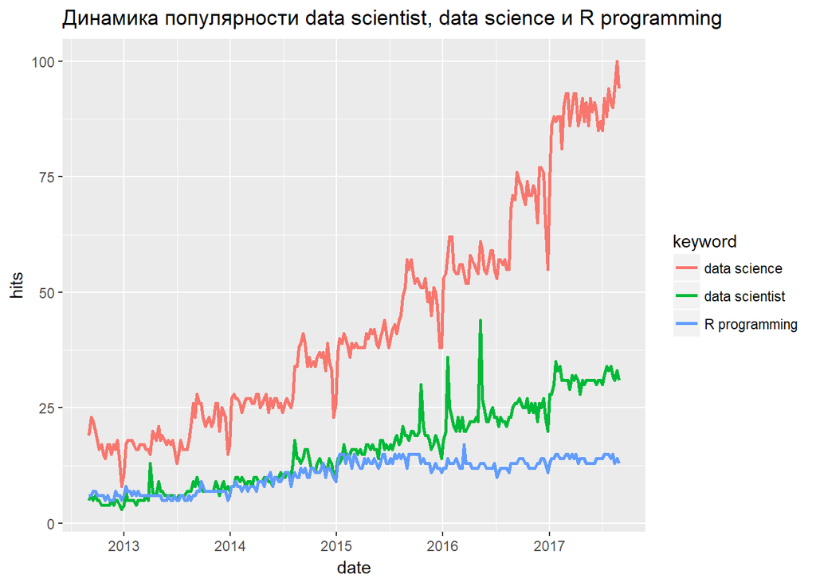

```r
ggplot(data=interest_over_time) +
  geom_line(mapping = aes(x=date, y=hits, color=keyword), size=1) +
  labs(title="Динамика популярности data scientist, data science и R programming")
```

Второй элемент списка `dtrend$interest_by_region` содержит распределение популярности ключевых слов по регионам. Найдем 10-ку лидеров по популярности каждого из ключевых слов:

[figure not shown]

```r
interest_by_region <- dtrend$interest_by_region

plot_top10_regions <- function(x){
top10_regions <- interest_by_region %>%
                      filter(keyword==x) %>%
                      group_by(location) %>%
                      summarise(hits=sum(hits)) %>%
                      arrange(desc(hits)) %>%
                      head(10)# поиск 10 регионов с наивысшей популярностью запроса

top10_regions <- top10_regions %>%
  mutate(location = fct_inorder(location)) # преобразования столбца location в фактор, чтобы на графике порядок отображения регионов был не в алфавитном порядке, а в соответствии с убывающими значениями hits
ggplot(top10_regions) +
  geom_bar(aes(x=location, y=hits, fill=location), stat="identity", show.legend = FALSE) +
  coord_flip() +
  labs(title=str_c("10-ка регионов-лидеров по популярности ", x))
}
plot_top10_regions("data scientist")
```

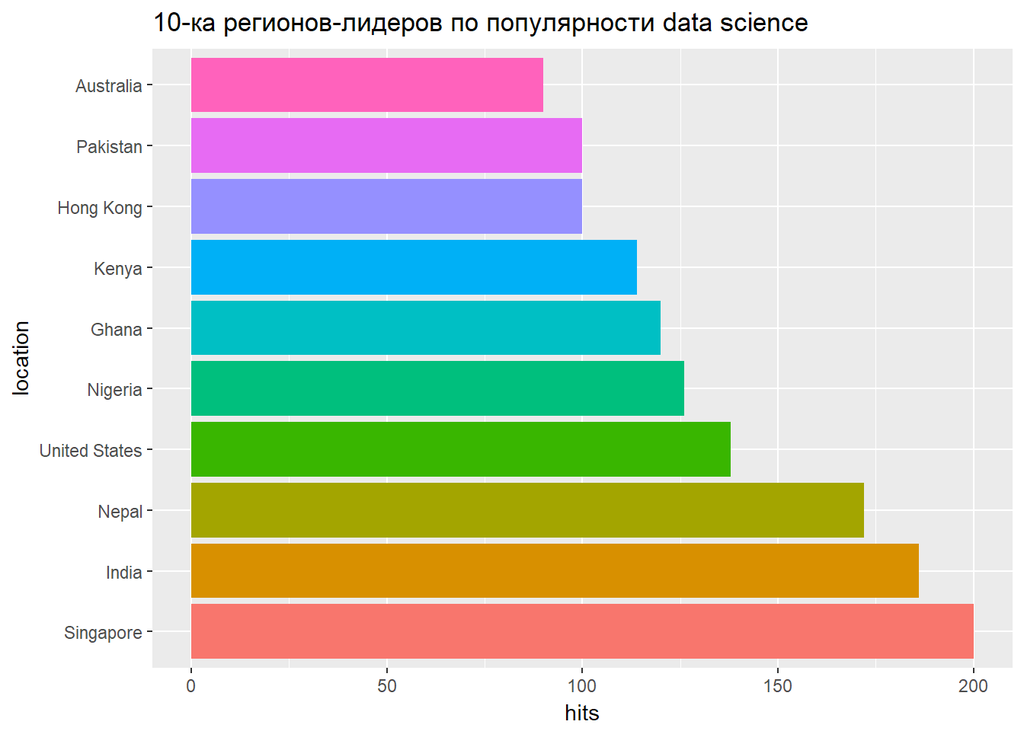

```r
plot_top10_regions("data science")
```

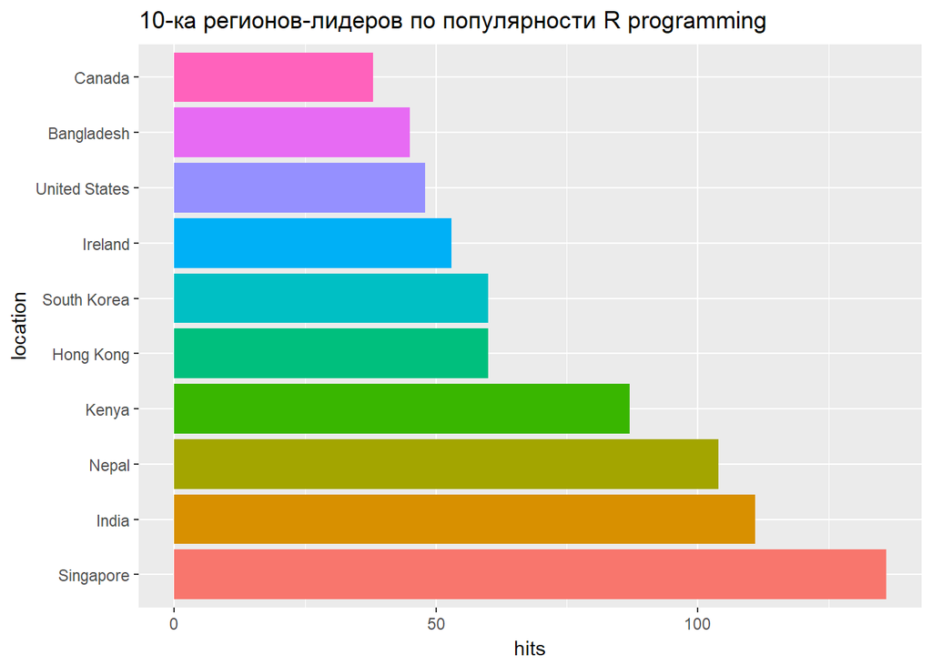

```r
plot_top10_regions("R programming")
```

Как можно увидеть из графиков, абсолютными лидерами по популярности “data scientist”, “data science” и “R programming” оказались Сингапур и Индия. В 10-ке преобладают страны Азии и Африки. Удивительно?

В других элементах списка `dtrend` содержатся данные о популярности запросов по данным ключевым словам в ряде административных округов и городов, а также информация о сопутствующих запросах. Например, популярные запросы, которые вводят вместе с ключевым словом “data scientist”:

```r
head(dtrend$related_queries %>% filter(keyword=="data scientist") %>% select(subject, value), 10)
```

```
##    subject                    value
## 1      100    salary data scientist
## 2       75      data scientist jobs
## 3       60             data science
## 4       45       data scientist job
## 5       40   what is data scientist
## 6       35             data analyst
## 7       30                 big data
## 8       30       big data scientist
## 9       30 what is a data scientist
## 10      25    become data scientist
```

Популярные запросы, которые вводят вместе с ключевым словом “data science”:

```r
head(dtrend$related_queries %>% filter(keyword=="data science") %>% select(subject, value), 10)
```

```
##    subject                   value
## 1      100         data in science
## 2       40        computer science
## 3       25    what is data science
## 4       25         what is science
## 5       25            what is data
## 6       25 data science university
## 7       20                big data
## 8       20          data analytics
## 9       20        big data science
## 10      20       data science jobs
```

Популярные запросы, которые вводят вместе с ключевым словом “R programming”:

```r
head(dtrend$related_queries %>% filter(keyword=="R programming") %>% select(subject, value), 10)
```

```
##    subject                  value
## 1      100       programming in r
## 2       85             r language
## 3       85 r programming language
## 4       30     programming with r
## 5       30      r programming pdf
## 6       25             r tutorial
## 7       25 r programming tutorial
## 8       20             r download
## 9       20 download r programming
## 10      20                 python
```

Изначально мы получили тренды популярности запросов по всему миру, однако есть возможность сравнить тренды в разных странах. Например, мы можем сравнить тренды популярности запроса “data scientist” в России и США:

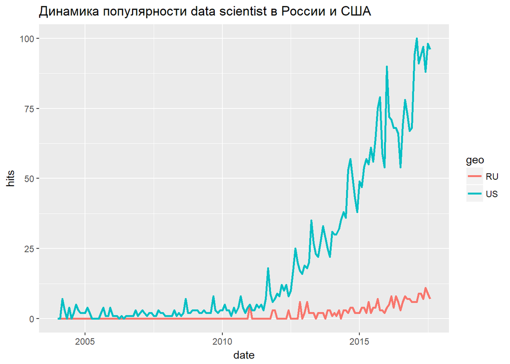

```r
dtrend_ru <- gtrends(c("data scientist"), geo=c("RU","US"), time="all")
ggplot(dtrend_ru[[1]]) +
  geom_line(mapping = aes(x = date, y = hits, color = geo), size = 1) +
  labs(title = "Динамика популярности data scientist в России и США")
```

Как можно увидеть из графика, в России рост популярности “data scientist” гораздо ниже, чем в США, однако тенденция к росту прослеживается отчетливо.